# Introdução aos modelos de regressão linear e não linear com o R

## Descrição do curso

Este curso irá abordar o uso de modelos de regressão, focando principalmente na Regressão Não-Linear. Serão disponibilizados exemplos práticos utilizando o RStudio como ferramenta para as execuções e serão abordados conceitos básicos do modelo de regressão linear simples, introdução ao modelo de regressão não-linear, métodos para obtenção de valores iniciais para os parâmetros e critérios de seleção de modelos.

## Objetivos

- Entender o conceito de análise de regressão, e saber como realizá-la com o auxílio da linguagem de programação R.
- Conhecer os modelos de regressão não linear.
- Aprender a obter chutes iniciais para realizar uma regressão não linear.
- Entender como utilizar alguns indicadores para selecionar os modelos adequados para um conjunto de dados.

## Unidade 1 - Introdução ao modelo de regressão linear geral

https://youtu.be/8DKF0m93dqw

Nesta unidade será introduzido o modelo de Regressão Linear, o que é e para que serve.

### 1.1 Introdução

Análise de Regressão: obter uma equação que explique satisfatoriamente a relação entre uma variável resposta e uma ou mais variáveis explicativas.

Prever valores da variável de interesse.

Uma análise de regressão linear pode ser:

- Simples: uma única variável explicativa. Exemplo: temperatura.
- Múltipla: mais de uma variável explicativa. Exemplo: Temperatura e concentração.

### 1.2 Modelo de Regressão Linear Simples (MRLS)

Relação linear entre a variável dependente (Y) e a variável independente (X).

$$y_{i} = \beta_{0} + \beta_{1}.x_{i} + \epsilon_{i}$$
### 1.3 Diagrama de Dispersão

Dado um conjunto de dados com duas variáveis quantitativas X e Y, pode-se construir um diagrama de dispersão.

Permite verificar se pode-se assumir um relacionamento linear entre as variáveis X e Y.

Tipos de correlação linear:

- positiva;
- negativa;
- nula.

Caso se observe uma correlação linear entre as variáveis X e Y, podemos quantificar essa associação, para confirmar o que foi observado.

Isso é feito pelo cálculo do **coeficiente de correlação linear de Pearson (r)**.

O coeficiente de correlação linear é de tal forma que -1 <= r <= 1.

Dessa forma:

- r < 0: correlação linear negativa.
- r > 0: correlação linear positiva.
- |r| próximo de 1: correlação linear forte.

### 1.4 Regressão Linear Simples

Ao se confirmar uma relação linear forrte, pode-se considerar uma **regressão linear simples** entre as variáveis, de forma a encontrar uma equação que explique de forma satisfatória essa relação. Essa relação terá a seguinte forma:

$$\hat{y}_{i} = \hat{\beta_{0}} + \hat{\beta_{1}} \times x_{i}$$

Em que:

$$\hat{\beta_{1}} = \frac{S_{XX}}{S_{XY}}$$
e

$$\hat{\beta_{0}} = \bar{y} - \hat{\beta_{1}} \times \bar{x}$$
onde:

$$\bar{x} = \frac{1}{n} \times \sum_{i=1}^{n}x$$

$$\bar{y} = \frac{1}{n} \times \sum_{i=1}^{n}y$$

$$S_{XX} = \sum_{i=1}^{n}X_{i}Y_{i} - \frac{\sum_{i=1}^{n}X_{i} \times
\sum_{i=1}^{n}Y_{i}}{n}$$
$$S_{XY} = \sum_{i=1}^{n}X_{i}^{2} - \frac{(\sum_{i=1}^{n}X_{i})²}{n}$$

- $\hat{\beta_{0}}$ representa o valor de Y quando X = 0;
- $\hat{\beta_{1}}$ representa o valor de Y quando X é incrementado em uma unidade.

### 1.5 Teste de Significância da Regressão

Para testar a significância da regressão, deve-se testar as hipóteses:

- $H_{0}$: $\hat{\beta_{1}} = 0$
- $H_{1}$: $\hat{\beta_{1}} \neq 0$

O **teste estatístico t** é utilizado para testar essas hipóteses.

Se a **hipótese nula** ($H_{0}$) for **aceita**, a **regressão não é significativa**, e não há uma relação linear entre as variáveis.

Ao contrário, se a **hipótese nula** for **rejeitada**, a **regressão é significativa**, e existe uma relação linear entre as variáveis.

**Regra de decisão**: A um determinado nível de significância, a decisão do teste de hipóteses se dá por:

- p-valor < nível de significância: reijeitar $H_{0}$.
- p-valor > nível de significância: aceitar $H_{0}$.

### 1.6 Coeficiente de Determinação ($R^{2}$)

Fornece a proporção da variação de Y explicada pela variável X.

Quando $R^{2}$ é próximo de 1, isso indica que a maior parte da variação de Y é explicada pelo modelo de regressão.

### 1.7 Exemplo

Considere o conjunto de dados a seguir:

Tabela 1: quantidade de procaína hidrolisada em moles/litro no plasma humano em função do tempo em minutos.

Fonte: Aven e Foldes (1951)

| Tempo (minutos) | Quantidade hidrolisada (moles/litro) |
| --- | --- |
| 2 | 3,5 |
| 3 | 5,7 |
| 5 | 9,9 |
| 8 | 16,3 |
| 10 | 19,3 |
| 12 | 25,7 |
| 14 | 28,2 |
| 15 | 32,6 |

Utilizando o R, vamos construir o diagrama de dispersão dos dados, calcularemos o coeficiente de correlação linear de Pearson e, em caso de um associação linear forte entre as variáveis X e Y, encontraremos a equação de regressão que modela a associação entre elas.

```r
x <- c(2, 3, 5, 8, 10, 12, 14, 15)

y <- c(3.5, 5.7, 9.9, 16.3, 19.3, 25.7, 28.2, 32.6)

print(length(x) == length(y))
```

```
## [1] TRUE
```

```r
# calcula o coeficiente de correlação de pearson
cor(x, y)
```

```
## [1] 0.9969554
```

```r
dados <- data.frame(x, y); dados
```

```
##    x    y
## 1  2  3.5
## 2  3  5.7
## 3  5  9.9
## 4  8 16.3
## 5 10 19.3
## 6 12 25.7
## 7 14 28.2
## 8 15 32.6
```

```r
# instancia o modelo de regressão linear
model_regressao <- lm(y ~ x, data = dados); model_regressao
```

```
##
## Call:
## lm(formula = y ~ x, data = dados)
##
## Coefficients:
## (Intercept)            x
##      -0.985        2.161
```

```r
summary(model_regressao)
```

```
##
## Call:
## lm(formula = y ~ x, data = dados)
##
## Residuals:
##     Min      1Q  Median      3Q     Max
## -1.3208 -0.2655  0.1230  0.3420  1.1763
##
## Coefficients:
##             Estimate Std. Error t value Pr(>|t|)
## (Intercept) -0.98502    0.67549  -1.458    0.195
## x            2.16058    0.06899  31.319 7.04e-08 ***
## ---
## Signif. codes:  0 '***' 0.001 '**' 0.01 '*' 0.05 '.' 0.1 ' ' 1
##
## Residual standard error: 0.9044 on 6 degrees of freedom
## Multiple R-squared:  0.9939, Adjusted R-squared:  0.9929
## F-statistic: 980.9 on 1 and 6 DF,  p-value: 7.039e-08
```

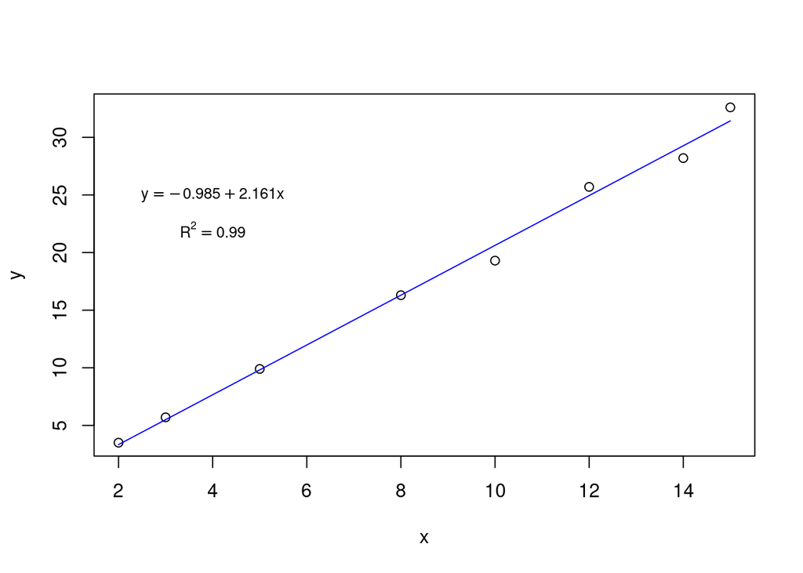

```r
# cria a instancia de uma curva
plot(x, y)
curve(-0.985 + 2.161 * x, add = T, col = "blue")
text(4, 25, expression(y == -0.985 + 2.161 * x), cex = 0.8)
text(4, 22, expression(R^2 == 0.99), cex = 0.8)
```

https://youtu.be/pjt1gktaZUk

### 1.8 Dados de Secagem

[output not shown]

NOTA: Essas são as 17 primeiras linha de dados de secagem. Esse conjunto de dados possui o total 48 linhas.

NOTA: A primeira coluna indica o tempo de secagem em minutos e a segunda, o peso final da flor em gramas.

```r
dados <- read.table("dados_secagem.txt", h = T)
attach(dados)
x <- tempo
y <- pf
plot(x, y)
reg <- lm( y ~ x)
summary(reg)
```

```
##
## Call:
## lm(formula = y ~ x)
##
## Residuals:
##      Min       1Q   Median       3Q      Max
## -0.13613 -0.08262 -0.00675  0.07705  0.17892
##
## Coefficients:
##               Estimate Std. Error t value Pr(>|t|)
## (Intercept)  0.7444486  0.0292483   25.45   <2e-16 ***
## x           -0.0029114  0.0001989  -14.64   <2e-16 ***
## ---
## Signif. codes:  0 '***' 0.001 '**' 0.01 '*' 0.05 '.' 0.1 ' ' 1
##
## Residual standard error: 0.09796 on 46 degrees of freedom
## Multiple R-squared:  0.8233, Adjusted R-squared:  0.8195
## F-statistic: 214.3 on 1 and 46 DF,  p-value: < 2.2e-16
```

```r
curve(0.7444486 - 0.0029114 * x, add = T, col = "blue")
reg2 <- lm(y ~ x + I(x^2), data = dados)
summary(reg2)
```

```
##
## Call:
## lm(formula = y ~ x + I(x^2), data = dados)
##
## Residuals:
##       Min        1Q    Median        3Q       Max
## -0.079570 -0.020850  0.005832  0.019890  0.069971
##
## Coefficients:
##               Estimate Std. Error t value Pr(>|t|)
## (Intercept)  9.786e-01  1.688e-02   57.98   <2e-16 ***
## x           -7.955e-03  2.938e-04  -27.08   <2e-16 ***
## I(x^2)       1.919e-05  1.085e-06   17.70   <2e-16 ***
## ---
## Signif. codes:  0 '***' 0.001 '**' 0.01 '*' 0.05 '.' 0.1 ' ' 1
##
## Residual standard error: 0.0351 on 45 degrees of freedom
## Multiple R-squared:  0.9778, Adjusted R-squared:  0.9768
## F-statistic: 991.2 on 2 and 45 DF,  p-value: < 2.2e-16
```

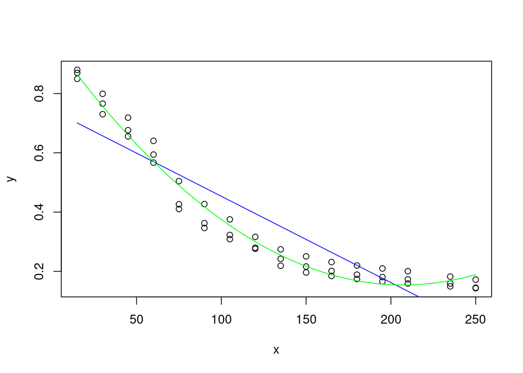

```r
curve(0.9786 - 0.007955 * x + 0.00001919 * x ^ 2, add = T, col = "green")
```

## Unidade 2 - Introdução ao modelo de regressão não linear

Nesta unidade abordaremos uma Estimação dos parâmetros (técnica da linearização, manipulate); a Seleção do modelo (R2, R2a, Erro médio estimado, erro médio residual) e o Cálculo de valores preditos.

### 2.1 Introdução

Os modelos de regressão apresentam, de modo geral, a seguinte forma:

$$Y = f(X, \theta) + \epsilon$$
Sendo:

- $f(X, \theta)$ a função das variáveis preditoras **X** e parâmetros **$\theta$** a serem estimados e **$\epsilon$** são os erros aleatórios.

Para variáveis biológicas, modelos lineares raramente explicam a relação entre as variáveis. Essas são, portanto, melhores descritas por **modelos não lineares**.

Os modelos não lineares são caracterizados por funções $f(X, \theta)$ não lineares em pelo menos um dos parâmetros $\theta_{i}$.

Existem diversos modelos de regressão não lineares. Eles possuem finalidades específicas. Alguns dos mais conhecidos são:

- Modelo de Mitscherlich;
- Modelo Logístico;
- Modelo de Gompertz;
- Modelo de Michaelis-Mentem.

### 2.2 Modelo de Mitscherlich

Esse modelo tem como uso principal o estudo da variação do crescimento de vegetais ou produção de determinada cultura (**Y**) em função da quantidade de nutrientes fornecida (**X**). Ele é dado pela seguinte função:

$$y = \alpha(1 - 10^{-\gamma(x + \theta)}) + \epsilon$$

### 2.3 Modelo Logístico

É um modelo utilizado para crescimento de populações humana, animais e vegetais. De modo usual $\theta > 0$ e $\beta > 0$, em que a função logística aparenta uma curva sigmóide.

$$y = \frac{\theta}{1 + e^{-(\alpha + \beta x)}} + \epsilon$$
### 2.4 Modelo de Gompertz

Modelo utilizado para descrever crescimentos, onde este é proporcional não ao tamanho da população, mas ao logaritmo deste tamanho. É dado pela função:

$$y = e^{\alpha + \beta \rho x} + \epsilon$$
Em que $\beta < 0$ e $0 < \rho < 1$ e a função de Gompertz é monotonicamente crescente.

### 2.5 Modelo de Michaelis-Menten

Modelo utilizado para estudos da taxa de reações químicas catalizadas por enzimas.

É dado pela função:

$$y = \frac{\theta_1 x}{x + \theta_2} + \epsilon$$
### 2.6 Dados de Secagem

Além dos modelos citados anteriormente, existem diversos outros modelos para diversos fins.

No que diz respeito a dados de secagem de plantas, por exemplo, uma série de modelos são utilizados na literatura (Tabela 1).

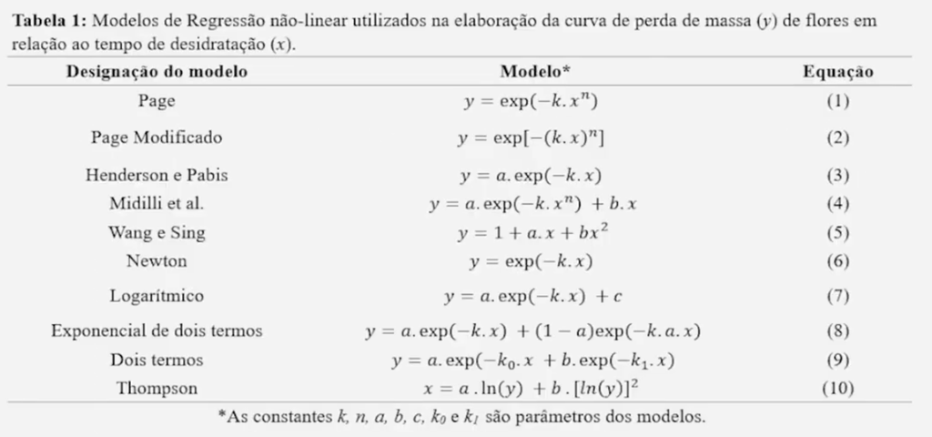

Tabela 1

### 2.7 Estimação de parâmetros

Como visto, os modelos de regressão possuem parâmetros, os quais devem ser estimados. Para isso, pode-se usar o **Método de Estimação por Mínimos Quadrados Ordinários**

### 2.8 Estimação por Mínimos Quadrados Ordinários

As estimativas do vetor de parâmetros $\theta$ para um modelo não linear são aquelas que minimizam a soma de quadrados dos erros, dada por:

$$S(\theta) = \sum_{i=1}^{n} (y_i - f(x_i, \theta))^{2}$$

Para encontrar os estimadores que geram tais estimativas, é preciso derivar $\S(\theta)$ com relação a cada elemento do vetor $\theta$ e igualar a **0**, obtendo-se p seguinte vetor de equações normais:

$$\sum_{i=1}^{n} (y_i - f(x_i, \theta))^{2} (\frac{\delta f(x_i,
\theta)}{\delta \theta_j})_{\theta = \hat{\theta}} = 0$$

Para modelos lineares esse sistema normalmente possui um vetor único de soluções para os parâmetros $\theta$, em que cada parâmetro depende unicamente dos dados observados.

Já para modelos não lineares, os estimadores $\hat{\theta}$ resultantes do sistema, em geral **NÃO** apresentam forma analítica e as soluções precisam ser obtidas por algum **método de aproximações iterativas**.

### 2.9 Métodos Iterativos

Os principais métodos iterativos são o método de Gauss-Newton, método de Davidon-Fletcher-Powell, método da descida mais íngreme (steepest descent, método da procura pelo gradiente conjugado, método da procura de NelderMead, algoritmo de Golub-Pereyra, entre outros.

### 2.10 Linearização

Todos os processos iterativos dependem da escolha de boas estimativas iniciais e os métodos de ajuste de uma regressão não linear não são exceção.

Uma técnica utilizada para encontrar estimativas iniciais para os parâmetros é a **técnica de linearização**.

Essa técnica consiste em transformar a função a fim de torná-la linear nos parâmetros.

Quando isso for possível, pode-se realizar uma regressão linear da variável transformada sobre os novos parâmetros e usar as estimativas dessa regressão (após aplicar a transformação inversa) como estimativas iniciais para o modelo não linear, ignorando o erro aleatório,

O conjunto de dados que será analisado se refere ao peso final após a secagem de flores de Viola x wittrockiana Gams em relação ao tempo de secagem.

Vamos ajustar ao conjunto de dados dois dos modelos não lineares citados anteioremente. Para isso, vamos utilizar a **técnica de linearização** para encontrar chutes iniciais para os parâmetros dos modelos.

### 2.11 Modelo de Newton

Vamos começar linearizando o modelo para encontrar o chute inicial do parâmetro k:

$$y = e^{-kx}$$
$$\ln{y} = \ln{e^{-kx}}$$

$$\ln{y} = -kx$$

Portanto, temos o seguinte modelo linearizado

$$z = -kx$$

Considere o modelo linear $z = \beta_0 + \beta_1 x$

Assim, no modelo linearizado temos:

$$k = -\beta_{1}$$
Onde :

$$z = \ln{y}$$

```r
library(nlstools)
read.table("dados_secagem.txt", h = T)
```

```
##    tempo     pf
## 1     15 0.8797
## 2     15 0.8496
## 3     15 0.8696
## 4     30 0.7990
## 5     30 0.7301
## 6     30 0.7659
## 7     45 0.7186
## 8     45 0.6554
## 9     45 0.6763
## 10    60 0.6404
## 11    60 0.5669
## 12    60 0.5940
## 13    75 0.5043
## 14    75 0.4262
```

[output cut: 34 more lines]

```r
attach(dados)
```

```
## Os seguintes objetos são mascarados por dados (pos = 4):
##
##     pf, tempo
```

```r
x <- tempo
y <- pf
z <- log(y)

model1 <- lm(z ~ x)
summary(model1)
```

```
##
## Call:
## lm(formula = z ~ x)
##
## Residuals:
##      Min       1Q   Median       3Q      Max
## -0.30216 -0.14723  0.01023  0.12889  0.35055
##
## Coefficients:
##               Estimate Std. Error t value Pr(>|t|)
## (Intercept) -0.1687580  0.0484649  -3.482   0.0011 **
## x           -0.0077612  0.0003295 -23.553   <2e-16 ***
## ---
## Signif. codes:  0 '***' 0.001 '**' 0.01 '*' 0.05 '.' 0.1 ' ' 1
##
## Residual standard error: 0.1623 on 46 degrees of freedom
## Multiple R-squared:  0.9234, Adjusted R-squared:  0.9218
## F-statistic: 554.7 on 1 and 46 DF,  p-value: < 2.2e-16
```

```r
model2 <- nls(y ~ exp(-k * x), data=dados, start=c(k = 0.0077612), )
summary(model2)
```

```
##
## Formula: y ~ exp(-k * x)
##
## Parameters:
##    Estimate Std. Error t value Pr(>|t|)
## k 0.0095043  0.0001934   49.15   <2e-16 ***
## ---
## Signif. codes:  0 '***' 0.001 '**' 0.01 '*' 0.05 '.' 0.1 ' ' 1
##
## Residual standard error: 0.04281 on 47 degrees of freedom
##
## Number of iterations to convergence: 4
## Achieved convergence tolerance: 6.881e-06
```

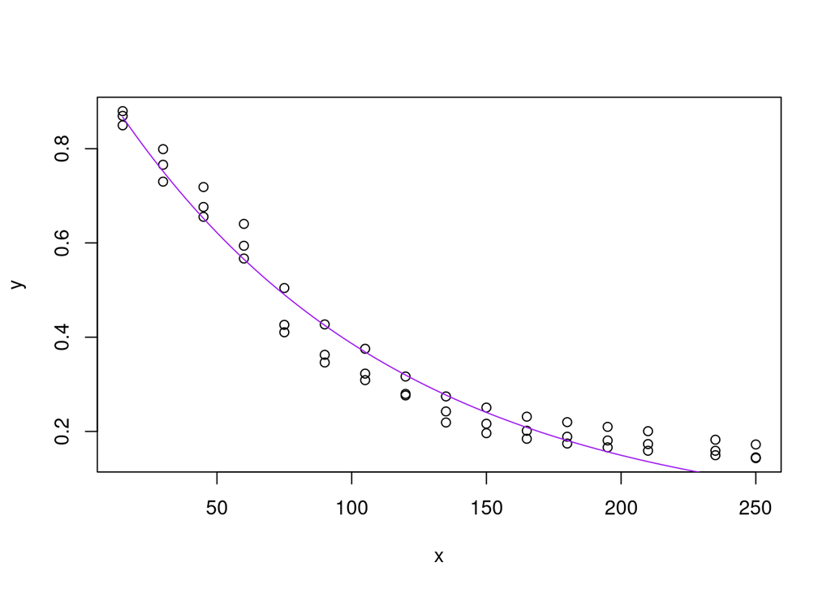

```r
plot(y ~ x)

curve(exp(-0.0095043 * x), add=T, col="purple")
```

Ajustaremos agora o **modelo de Michaelis-Menten** aos dados. Iniciaremos o processo linearizando o modelo para encontrar os chutes iniciais dos parâmetros:

$$y = \frac{\theta_1 x}{x + \theta_2}$$
$$\frac{1}{y} = \frac{1}{\frac{\theta_1 x}{x + \theta_2}}$$

$$\frac{1}{y} = \frac{x + \theta_2}{\theta_1 x}$$
$$\frac{1}{y} = \frac{x}{\theta_1 x} + \frac{\theta_2}{\theta_1 x}$$
$$\frac{1}{y} = \frac{1}{\theta_1} + \frac{\theta_2}{\theta_1}.\frac{1}{x}$$
$$y^{*} = \beta_0 + \beta_1 \times x^{*}$$

Onde:

$$y^{*} = \frac{1}{y}$$

$$x^{*} = \frac{1}{x}$$

$$\beta_1 = \frac{\theta_2}{\theta_1}$$
$$\beta_0 = \frac{1}{\theta_1}$$

```r
read.table("dados_secagem.txt", h = T)
```

```
##    tempo     pf
## 1     15 0.8797
## 2     15 0.8496
## 3     15 0.8696
## 4     30 0.7990
## 5     30 0.7301
## 6     30 0.7659
## 7     45 0.7186
## 8     45 0.6554
## 9     45 0.6763
## 10    60 0.6404
## 11    60 0.5669
## 12    60 0.5940
## 13    75 0.5043
## 14    75 0.4262
```

[output cut: 34 more lines]

```r
attach(dados)
```

```
## Os seguintes objetos são mascarados por dados (pos = 3):
##
##     pf, tempo
```

```
## Os seguintes objetos são mascarados por dados (pos = 5):
##
##     pf, tempo
```

```r
x <- tempo
y <- pf

u <- 1/x
v <- 1/y

model1 <- lm(v ~ u)

summary(model1)
```

```
##
## Call:
## lm(formula = v ~ u)
##
## Residuals:
##      Min       1Q   Median       3Q      Max
## -1.95227 -1.10769 -0.09235  1.12982  2.44059
##
## Coefficients:
##             Estimate Std. Error t value Pr(>|t|)
## (Intercept)   4.8611     0.2609  18.633  < 2e-16 ***
## u           -80.8410    12.4386  -6.499 5.15e-08 ***
## ---
## Signif. codes:  0 '***' 0.001 '**' 0.01 '*' 0.05 '.' 0.1 ' ' 1
##
## Residual standard error: 1.341 on 46 degrees of freedom
## Multiple R-squared:  0.4787, Adjusted R-squared:  0.4674
## F-statistic: 42.24 on 1 and 46 DF,  p-value: 5.151e-08
```

```r
# Extrair apenas os valores numéricos dos coeficientes
coeficientes <- as.numeric(coef(model1))

# Atribuir os coeficientes a variáveis separadas
intercepto <- coeficientes[1]
coef_u <- coeficientes[2]

# Imprimir os valores
print(intercepto)
```

```
## [1] 4.86114
```

```r
print(coef_u)
```

```
## [1] -80.84099
```

$$\beta_0 = \frac{1}{\theta_1} = 4.8611$$
$$\theta_1 = 0.2057148$$

$$\beta_1 = \frac{\theta_2}{\theta_1} = -80.8410$$
$$\theta_2 = -80.8410 \times \theta_1 = -80.8410 \times 0.2057148 =
-16.63019$$

```r
library(nlstools)

read.table("dados_secagem.txt", h = T)
```

```
##    tempo     pf
## 1     15 0.8797
## 2     15 0.8496
## 3     15 0.8696
## 4     30 0.7990
## 5     30 0.7301
## 6     30 0.7659
## 7     45 0.7186
## 8     45 0.6554
## 9     45 0.6763
## 10    60 0.6404
## 11    60 0.5669
## 12    60 0.5940
## 13    75 0.5043
## 14    75 0.4262
```

[output cut: 34 more lines]

```r
attach(dados)
```

```
## Os seguintes objetos são mascarados por dados (pos = 3):
##
##     pf, tempo
```

```
## Os seguintes objetos são mascarados por dados (pos = 4):
##
##     pf, tempo
```

```
## Os seguintes objetos são mascarados por dados (pos = 6):
##
##     pf, tempo
```

```r
x <- tempo
y <- pf

u <- 1/x
v <- 1/y

model1 <- lm(v ~ u)

summary(model1)
```

```
##
## Call:
## lm(formula = v ~ u)
##
## Residuals:
##      Min       1Q   Median       3Q      Max
## -1.95227 -1.10769 -0.09235  1.12982  2.44059
##
## Coefficients:
##             Estimate Std. Error t value Pr(>|t|)
## (Intercept)   4.8611     0.2609  18.633  < 2e-16 ***
## u           -80.8410    12.4386  -6.499 5.15e-08 ***
## ---
## Signif. codes:  0 '***' 0.001 '**' 0.01 '*' 0.05 '.' 0.1 ' ' 1
##
## Residual standard error: 1.341 on 46 degrees of freedom
## Multiple R-squared:  0.4787, Adjusted R-squared:  0.4674
## F-statistic: 42.24 on 1 and 46 DF,  p-value: 5.151e-08
```

```r
# Extrair apenas os valores numéricos dos coeficientes
coeficientes <- as.numeric(coef(model1))

# Atribuir os coeficientes a variáveis separadas
intercepto <- coeficientes[1]
coef_u <- coeficientes[2]

beta0 <-  intercepto

beta1 <- coef_u

theta1 <- 1/beta0; theta1
```

```
## [1] 0.2057131
```

```r
theta2 <- beta1 * theta1; theta2
```

```
## [1] -16.63005
```

```r
model2 <- nls(y ~ ((t1 * x) / (x + t2)), data=dados, start=c(t1=theta1, t2=theta2), trace=T)
```

```
## 24.04831    (6.07e+00): par = (0.2057131 -16.63005)
## 9.919243    (3.39e+00): par = (0.2700368 -19.51969)
## 6.582943    (6.66e-01): par = (0.1843888 -26.64727)
## 4.811455    (1.53e-01): par = (0.167426 -25.3047)
## 4.701532    (9.80e-03): par = (0.1423231 -25.40371)
## 4.701315    (1.09e-03): par = (0.1433906 -25.35515)
## 4.701311    (6.62e-04): par = (0.1434154 -25.36106)
## 4.701311    (4.41e-05): par = (0.1434791 -25.35771)
## 4.701311    (2.99e-06): par = (0.1434748 -25.35793)
```

```r
summary(model2)
```

```
##
## Formula: y ~ ((t1 * x)/(x + t2))
##
## Parameters:
##     Estimate Std. Error t value Pr(>|t|)
## t1   0.14347    0.03591   3.995 0.000231 ***
## t2 -25.35793    1.49499 -16.962  < 2e-16 ***
## ---
## Signif. codes:  0 '***' 0.001 '**' 0.01 '*' 0.05 '.' 0.1 ' ' 1
##
## Residual standard error: 0.3197 on 46 degrees of freedom
##
## Number of iterations to convergence: 8
## Achieved convergence tolerance: 2.992e-06
```

```r
# Extrair apenas os valores numéricos dos coeficientes
coeficientes <- as.numeric(coef(model2))
summary(model2)
```

```
##
## Formula: y ~ ((t1 * x)/(x + t2))
##
## Parameters:
##     Estimate Std. Error t value Pr(>|t|)
## t1   0.14347    0.03591   3.995 0.000231 ***
## t2 -25.35793    1.49499 -16.962  < 2e-16 ***
## ---
## Signif. codes:  0 '***' 0.001 '**' 0.01 '*' 0.05 '.' 0.1 ' ' 1
##
## Residual standard error: 0.3197 on 46 degrees of freedom
##
## Number of iterations to convergence: 8
## Achieved convergence tolerance: 2.992e-06
```

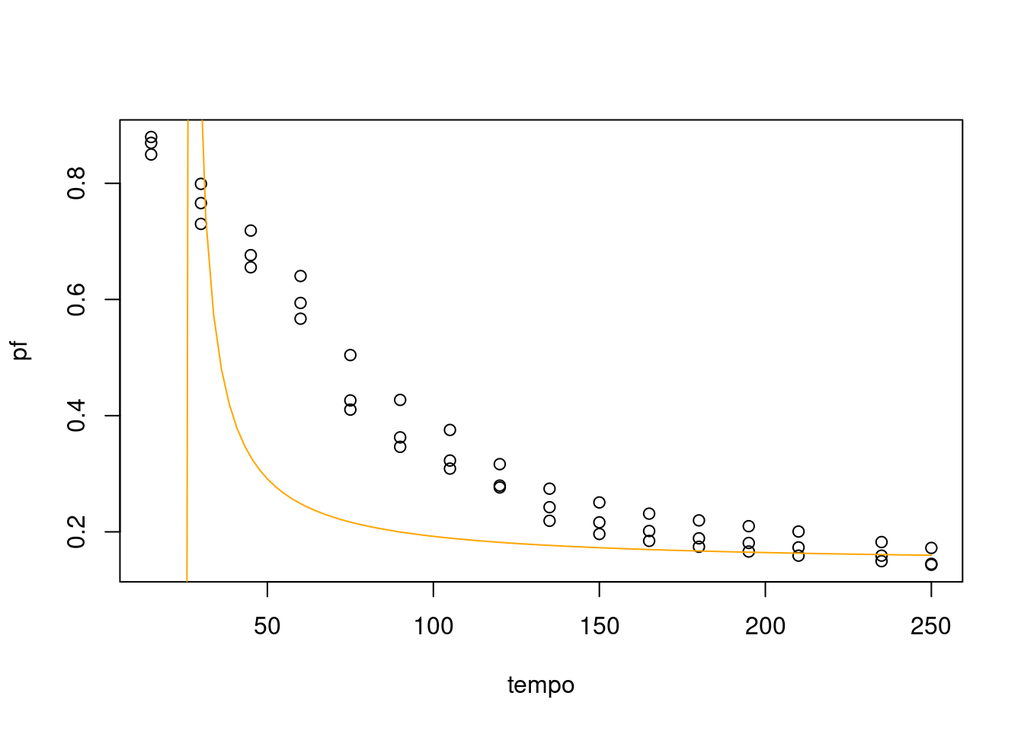

```r
# Atribuir os coeficientes a variáveis separadas
intercepto <- coeficientes[1]
coef_u <- coeficientes[2]


plot(pf ~ tempo)
curve(intercepto * x / (x + coef_u), add=T, col="orange")
```

**Questão 1**: O Objetivo do experimento foi avaliar o efeito de diferentes concentrações de Sulfato de Alumínio (g) sobre o comprimento (mm) de raiz de alface (Grand rapids).

| Concentração (x) | 0 | 0,04 | 0,06 | 0,16 | 0,32 | 0,64 |
| --- | --- | --- | --- | --- | --- | --- |
| Comprimento (y) | 10,67 | 7,64 | 7,73 | 2,58 | 2,38 | 0,02 |

**Questão 2**: Os dados a seguir são referentes a produção (t/ha) (y) de cana-de-açúcar com relação aos níveis de doses (kg/ha) de um nutriente (x).

| x | -5 | -3 | -1 | 1 | 3 | 5 |
| --- | --- | --- | --- | --- | --- | --- |
| y | 127 | 151 | 379 | 421 | 460 | 426 |

(DICA: use o comando manipulate no R para encontrar chutes iniciais adequados. Caso não consiga, use A = 450, b = −6 e c = 0,2 como chutes iniciais).

1. O diagrama de dispersão dos dados sugere um comportamento não linear entre a produção de cana-de-açucar e os níveis de doses do nutriente.
2. Considerando o ajuste do modelo de Mitscherlich aos dados, o Erro Médio Estimado é de 18,94%.
3. Considerando o modelo de Mitscherlich, as estimativas de mínimos quadrados para os parâmetros A, b e c são 523,3, -6,03 e 0,0867, respectivamente.
4. Considerando o ajuste do modelo de Mitscherlich aos dados, o coeficiente de determinação ajustado é de 79,71%.
5. Considerando o ajuste do modelo de Mitscherlich aos dados, a produção média esperada para x=2 é de aproximadamente 418 t/ha.

**Questão 3**: Seja o seguinte conjunto de dados, que considera a relação observada entre as variáveis massa de fertilizante (g/m²) e produção de grama (g/m²).

| Massa de fertilizante (x) | 25 | 50 | 75 | 100 | 125 | 150 | 175 | 200 | 225 | 250 |
| --- | --- | --- | --- | --- | --- | --- | --- | --- | --- | --- |
| Produção de grama (y) | 84 | 80 | 90 | 134 | 148 | 169 | 206 | 244 | 212 | 248 |

Considerando o ajuste de um modelo de regressão linear simples do tipo y = ß0 + ß1_x_ aos dados, assinale a alternativa incorreta.

**Questão 4**: Um estudo foi feito para investigar o efeito de um desinfetante. Foram preparadas soluções, nas quais o desinfetante foi diluído em quantidades fixas de água, para concentrações do desinfetante de 1% a 8%. Foi observado o número de bactérias que sobreviveram, após superfícies serem limpas com uma das soluções.

| Concentração (x) | 1 | 1 | 2 | 2 | 3 | 3 | 3 | 3 | 3 | 3 | 5 | 5 | 5 | 5 | 7 | 8 |
| --- | --- | --- | --- | --- | --- | --- | --- | --- | --- | --- | --- | --- | --- | --- | --- | --- |
| Nº de bactérias (y) | 29 | 32 | 26 | 25 | 21 | 24 | 26 | 28 | 21 | 22 | 14 | 24 | 13 | 15 | 18 | 13 |

**Questão 5**: Considere o seguinte conjunto de dados, referente ao conteúdo acumulado de potássio liberado no solo (mg) (y) dias após a incubação de esterco de codorna (x – dias).

| x | y |  |  |
| --- | --- | --- | --- |
| 15 | 51,03 | 57,76 | 26,60 |
| 30 | 60,65 | 87,07 | 64,67 |
| 45 | 91,28 | 105,22 | 72,74 |
| 60 | 81,88 | 97,62 | 90,14 |
| 75 | 89,88 | 113,22 | 90,91 |
| 90 | 115,39 | 112,63 | 87,51 |
| 120 | 104,69 | 120,58 | 114,32 |
| 150 | 130,07 | 117,65 | 111,69 |
| 180 | 128,54 | 126,88 | 127,00 |
| 210 | 134,17 | 149,66 | 118,25 |
| 240 | 132,67 | 154,48 | 129,11 |
| 270 | 151,83 | 147,66 | 127,30 |

Pelo diagrama de dispersão dos dados, é possível notar a presença de uma relação não-linear entre as variáveis conteúdo acumulado de potássio liberado no solo e dias após a incubação de esterco de codorna.

Questão 6: Considere os dados experimentais referentes y (comprimento em cm de um tipo de feijoeiro) obtidos em função de x (quantidade de água em ml observada em suas raízes).

| y | 1,3 | 1,3 | 1,9 | 3,4 | 5,3 | 7,1 | 10,6 | 13,5 | 16,0 | 16,4 | 18,3 | 20,9 | 20,5 | 21,3 |
| --- | --- | --- | --- | --- | --- | --- | --- | --- | --- | --- | --- | --- | --- | --- |
| x | 0,5 | 1,0 | 1,5 | 2,0 | 2,5 | 3,0 | 3,5 | 4,0 | 4,5 | 5,0 | 5,5 | 6,0 | 6,5 | 7,0 |

Questão 7: Considere o seguinte conjunto de dados, em que a variável preditora x corresponde ao número de dias que pacientes de um hospital ficaram hospitalizados e a variável resposta y corresponde a um índice de prognóstico para o tempo de recuperação, sendo que valores grandes indicam um bom prognóstico.

| x | 2 | 5 | 7 | 10 | 14 | 19 | 26 | 31 | 34 | 38 | 45 | 52 | 53 | 60 | 65 |
| --- | --- | --- | --- | --- | --- | --- | --- | --- | --- | --- | --- | --- | --- | --- | --- |
| y | 54 | 50 | 45 | 37 | 35 | 25 | 20 | 16 | 18 | 13 | 8 | 11 | 8 | 4 | 6 |

Questão 8: Considere os dados experimentais referentes y (comprimento em cm de um tipo de feijoeiro) obtidos em função de x (quantidade de água em ml observada em suas raízes).

| y | 1,3 | 1,3 | 1,9 | 3,4 | 5,3 | 7,1 | 10,6 | 13,5 | 16,0 | 16,4 | 18,3 | 20,9 | 20,5 | 21,3 |
| --- | --- | --- | --- | --- | --- | --- | --- | --- | --- | --- | --- | --- | --- | --- |
| x | 0,5 | 1,0 | 1,5 | 2,0 | 2,5 | 3,0 | 3,5 | 4,0 | 4,5 | 5,0 | 5,5 | 6,0 | 6,5 | 7,0 |

Considerando esses modelos, assinale a alternativa correta.

1. Após ajuste dos três modelos aos dados e com relação ao erro médio relativo (EMR) , vale que M2 > M1 > M3
2. Após ajuste dos três modelos aos dados e com relação ao erro médio estimado (EME) , vale que M1 > M2 > M3
3. Após ajuste dos três modelos aos dados e com relação ao coeficiente de determinação (R2), vale que M3 > M2 > M1
4. Considerando indicadores de qualidade de ajuste coeficiente de determinação ajustado, erro médio relativo e erro médio estimado, pode-se concluir que o modelo M1 (Gompertz) é o mais adequado.
5. Após ajuste dos três modelos aos dados e com relação ao coeficiente de determinação ajustado (R2a), vale que M2 > M1 > M3

## Referências

- CHARNET, et al. Análise de modelos de regressão linear: com aplicações.
2. ed. Campinas: Editora da UNICAMP, 2008. 368p
- FERNANDES, T. Curva de crescimento do fruto do cafeeiro em diferentes alinhamentos de plantio utilizando modelos não lineares. Dissertação (Mestrado)
- Universidade Federal de Lavras. Lavras, 2012.
- FONSECA, J. Composição centesimal e modelagem da curva de Desidratação para perda de massa de Viola × wittrockiana. Trabalho de Conclusão de curso (Curso de Ciência e Tecnologia de Alimentos) - Universidade Federal do Pampa. Itaqui, 2018.
- GASPARIN, P. P. (2012). Secagem da Mentha piperita em leito fixo utilizando diferentes temperaturas e velocidades de ar.
- R CORE TEAM (2021). R: A language and environment for statistical computing. R Foundation for Statistical Computing, Vienna, Austria. URL https://www.R-project.org/.
- RADÜNZ, L. L. et al. Avaliação da cinética de secagem de carqueja. Revista engenharia na agricultura - REVENG, v. 19, n. 1, p. 19–27, 26 jan. 2011. doi10.13083/reveng.v19i1.147
- RITZ, C.; STREIBIG, J. C. Nonlinear Regression with R. 2009. 151p. https://doi.org/10.1007/978-0-387-09616-2
- SILVA, L A.; ZAMBIAZI, R. C.; CHAVES, F. C.; FISCHER, S. Z. (2015). Avaliação das condições de extração sobre o teor de compostos fenólicos totais de Viola x wittrockiana. In: Congresso Brasileiro de Processamento mínimo e Pós-colheita de frutas, flores e hortaliças, 001. Aracaju-SE.
- TATTAR, P. N.; RAMAIAH, S.; MANJUNATH, B. G. A course in Statistics with R, John Wiley & Sons, 2016.
- VEN, M., FOLDES, F. The Chemical Kinetics of Procaine and Chloroprocaine Hydrolysis. Science, 24 Aug 1951. https://doi.org/10.1126/science.114.2956.206.b
- VERZANI, J. Getting Started with RStudio, O’Reilly Media, Inc., 2011.